# Lesson 3

### What to Do First?

Notes: Ask questions! ***

### Pseudo-Facebook User Data

Notes:

```r
pf = read.csv(file = 'pseudo_facebook.tsv', sep = '\t')
head(pf)
```

```
##    userid age dob_day dob_year dob_month gender tenure friend_count
## 1 2094382  14      19     1999        11   male    266            0
## 2 1192601  14       2     1999        11 female      6            0
## 3 2083884  14      16     1999        11   male     13            0
## 4 1203168  14      25     1999        12 female     93            0
## 5 1733186  14       4     1999        12   male     82            0
## 6 1524765  14       1     1999        12   male     15            0
##   friendships_initiated likes likes_received mobile_likes
## 1                     0     0              0            0
## 2                     0     0              0            0
## 3                     0     0              0            0
## 4                     0     0              0            0
## 5                     0     0              0            0
## 6                     0     0              0            0
##   mobile_likes_received www_likes www_likes_received
## 1                     0         0                  0
## 2                     0         0                  0
## 3                     0         0                  0
## 4                     0         0                  0
## 5                     0         0                  0
## 6                     0         0                  0
```

### Histogram of Users’ Birthdays

Notes:

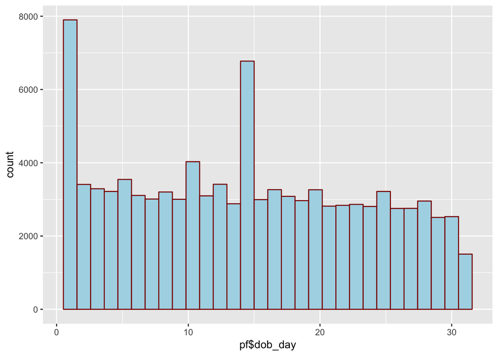

```r
#install.packages('ggplot2')
library(ggplot2)
#install.packages('ggthemes', dependencies = TRUE)
library('ggthemes')
ggplot(data = pf, aes(x = pf$dob_day)) +
  geom_histogram(bins = 30, color = 'dark red', fill = 'light blue')
```

#### What are some things that you notice about this histogram?

Response: Many people has left 1st as their DOB Day.

### Moira’s Investigation

Notes:She feels the same !

### Estimating Your Audience Size

Notes:

#### Think about a time when you posted a specific message or shared a photo on Facebook. What was it?

Response: Yoga camp

#### How many of your friends do you think saw that post?

Response: 100

#### Think about what percent of your friends on Facebook see any posts or comments that you make in a month. What percent do you think that is?

Response: 10%

### Perceived Audience Size

Notes:

### Faceting

Notes:

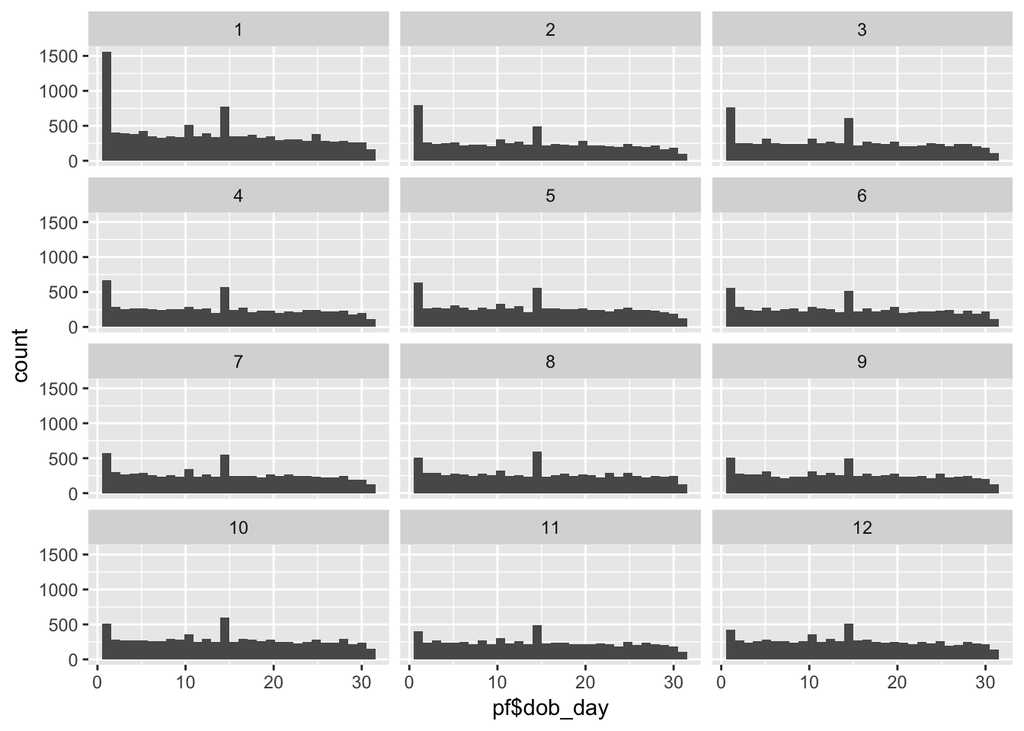

```r
ggplot(data = pf, aes(x = pf$dob_day)) +
  geom_histogram(bins = 30) +
  facet_wrap( ~ pf$dob_month, ncol = 3)
```

#### Let’s take another look at our plot. What stands out to you here?

Response: January 1st

### Be Skeptical - Outliers and Anomalies

Notes:

### Moira’s Outlier

Notes: #### Which case do you think applies to Moira’s outlier? Response: January 1st

### Friend Count

Notes:

#### What code would you enter to create a histogram of friend counts?

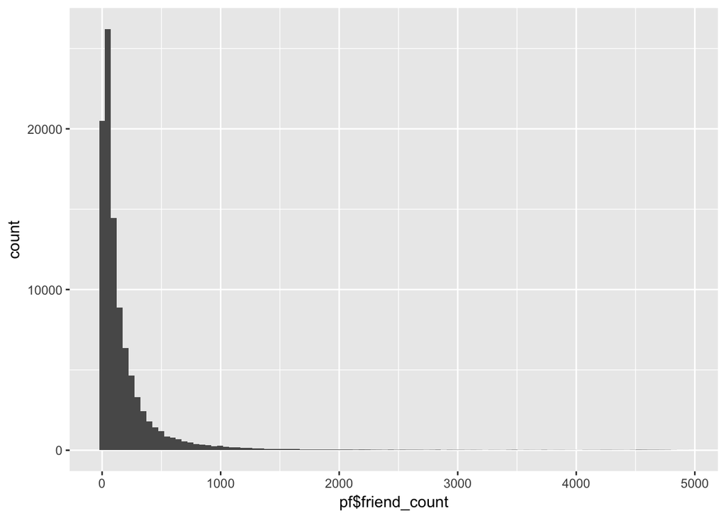

```r
ggplot(data = pf, aes(x = pf$friend_count)) +
  geom_histogram(bins = 100)
```

### Limiting the Axes

Notes:

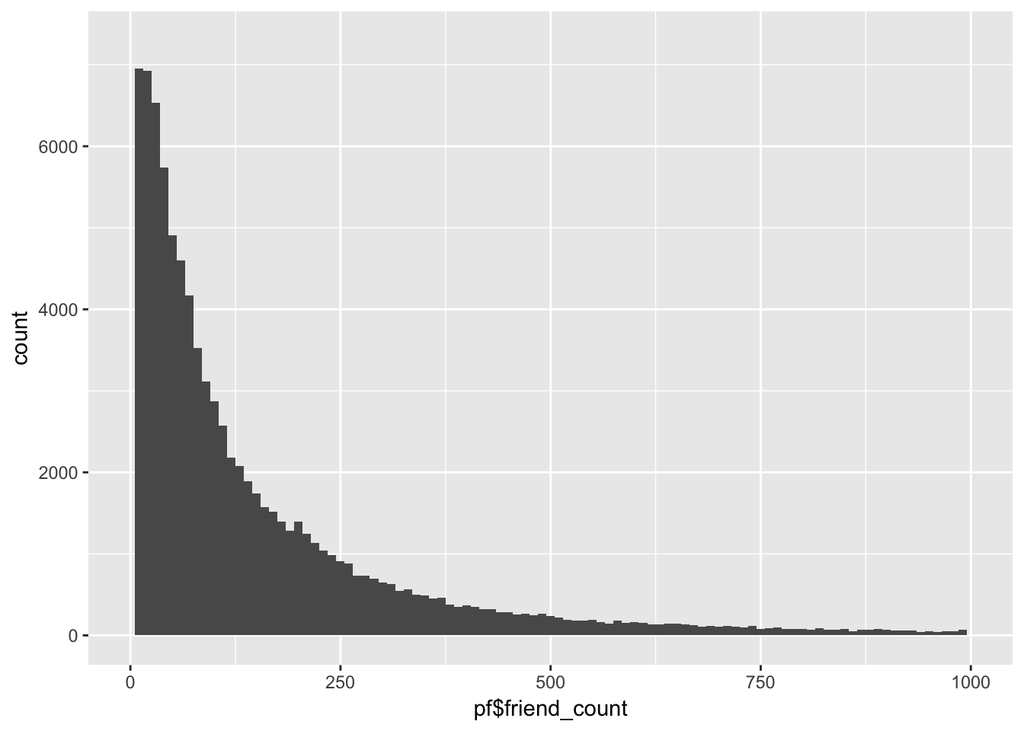

```r
ggplot(data = pf, aes(x = pf$friend_count)) +
  geom_histogram(binwidth = 10) +
  scale_x_continuous(limits = c(0,1000))
```

### Exploring with Bin Width

Notes:

### Adjusting the Bin Width

Notes:

### Faceting Friend Count

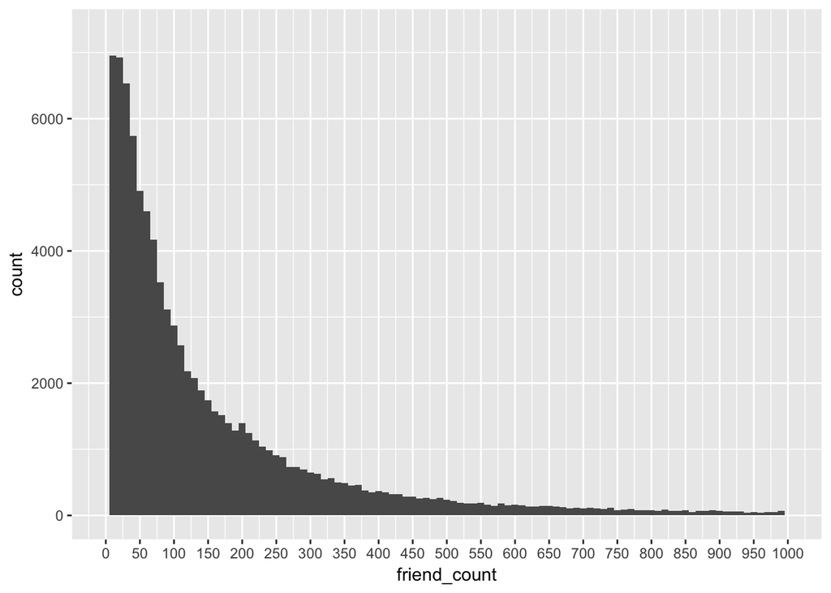

```r
# What code would you add to create a facet the histogram by gender?
# Add it to the code below.
qplot(x = friend_count, data = pf, binwidth = 10) +
  scale_x_continuous(limits = c(0, 1000),
                     breaks = seq(0, 1000, 50))
```

### Omitting NA Values

Notes:

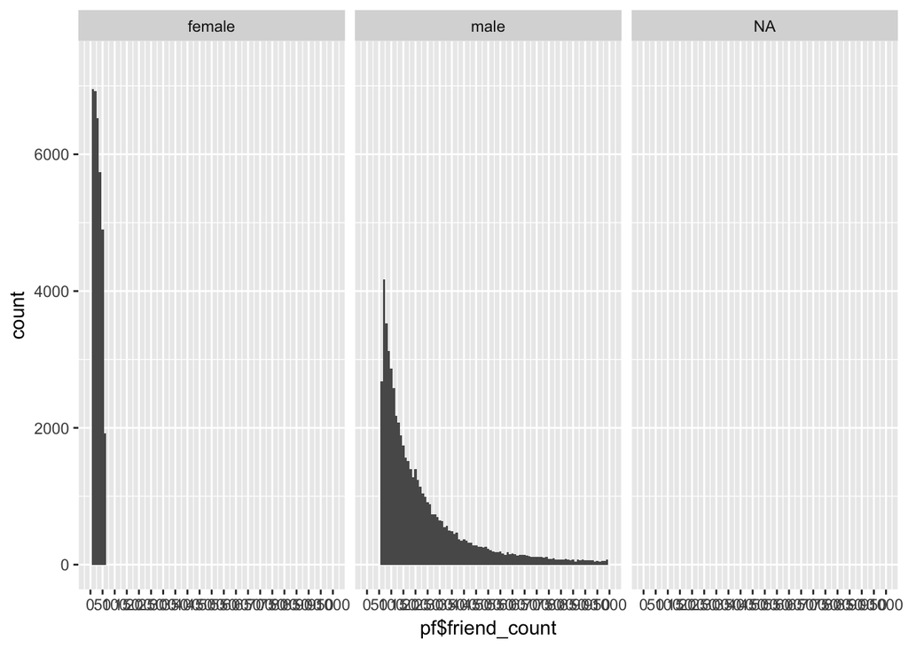

```r
ggplot(data = pf, aes(x = pf$friend_count)) +
  geom_histogram(binwidth = 10) +
  scale_x_continuous(limits = c(0,1000), breaks = seq(0,1000,50)) +
  facet_wrap( ~ pf$gender)
```

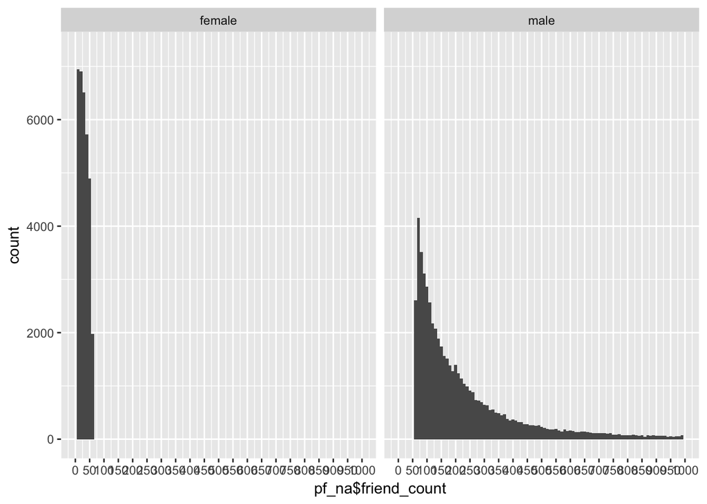

```r
pf_na = subset(pf, !is.na(pf$gender))
ggplot(data = pf_na, aes(x = pf_na$friend_count)) +
  geom_histogram(binwidth = 10) +
  scale_x_continuous(limits = c(0,1000), breaks = seq(0,1000,50)) +
  facet_wrap( ~ pf_na$gender)
```

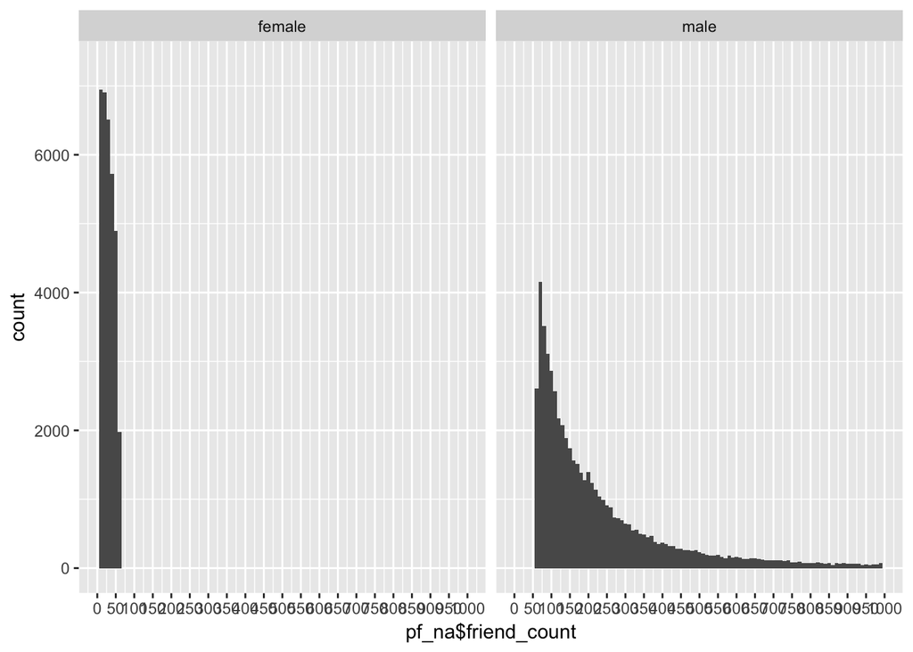

```r
pf_na = na.omit(pf)
ggplot(data = pf_na, aes(x = pf_na$friend_count)) +
  geom_histogram(binwidth = 10) +
  scale_x_continuous(limits = c(0,1000), breaks = seq(0,1000,50)) +
  facet_wrap( ~ pf_na$gender)
```

### Statistics ‘by’ Gender

Notes:

```r
summary(pf$gender)
```

```
## female   male   NA's
##  40254  58574    175
```

```r
by(data = pf$friend_count, INDICES = pf$gender, FUN = summary)
```

```
## pf$gender: female
##    Min. 1st Qu.  Median    Mean 3rd Qu.    Max.
##       0      37      96     242     244    4923
## --------------------------------------------------------
## pf$gender: male
##    Min. 1st Qu.  Median    Mean 3rd Qu.    Max.
##       0      27      74     165     182    4917
```

#### Who on average has more friends: men or women?

Response:Women, ofcourse!

#### What’s the difference between the median friend count for women and men?

Response:22

#### Why would the median be a better measure than the mean?

Response:Robust to outlieners

### Tenure

Notes:

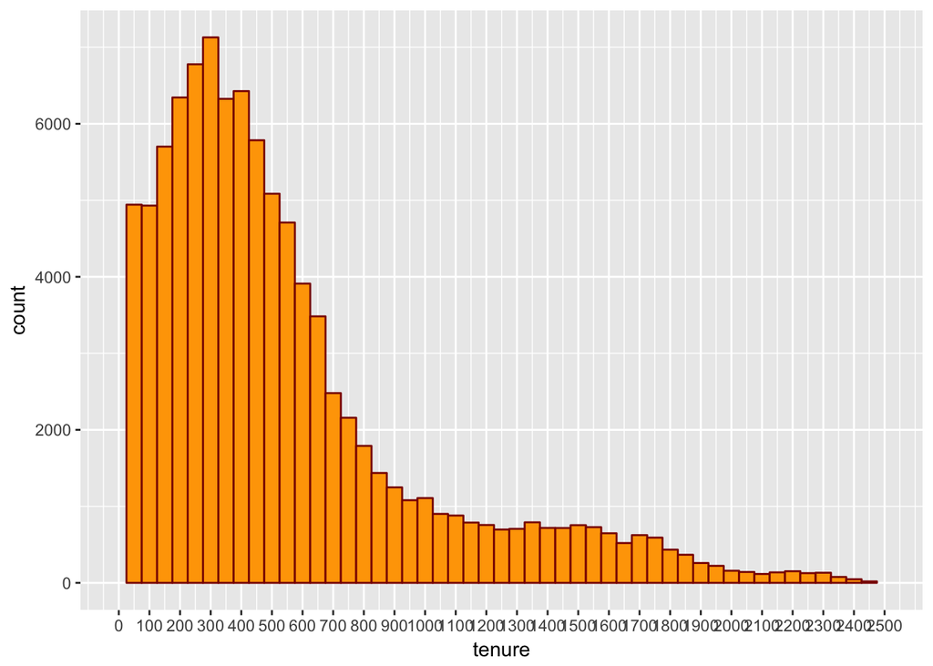

```r
ggplot(data = pf[!is.na(pf$gender),], aes(x = tenure )) +
  geom_histogram(binwidth = 50, color = "dark red", fill = "orange") +
  scale_x_continuous(limits = c(0, 2500), breaks = seq(0,2500,100))
```

#### How would you create a histogram of tenure by year?

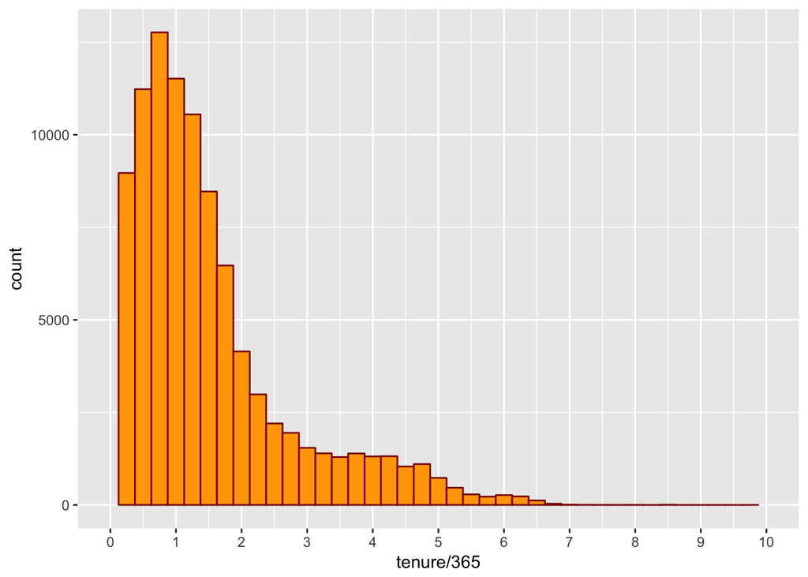

```r
ggplot(data = pf[!is.na(pf$gender),], aes(x = tenure/365 )) +
  geom_histogram(binwidth = .25, color = "dark red", fill = "orange") +
  scale_x_continuous(limits = c(0, 10), breaks = seq(0,10,1))
```

### Labeling Plots

Notes:

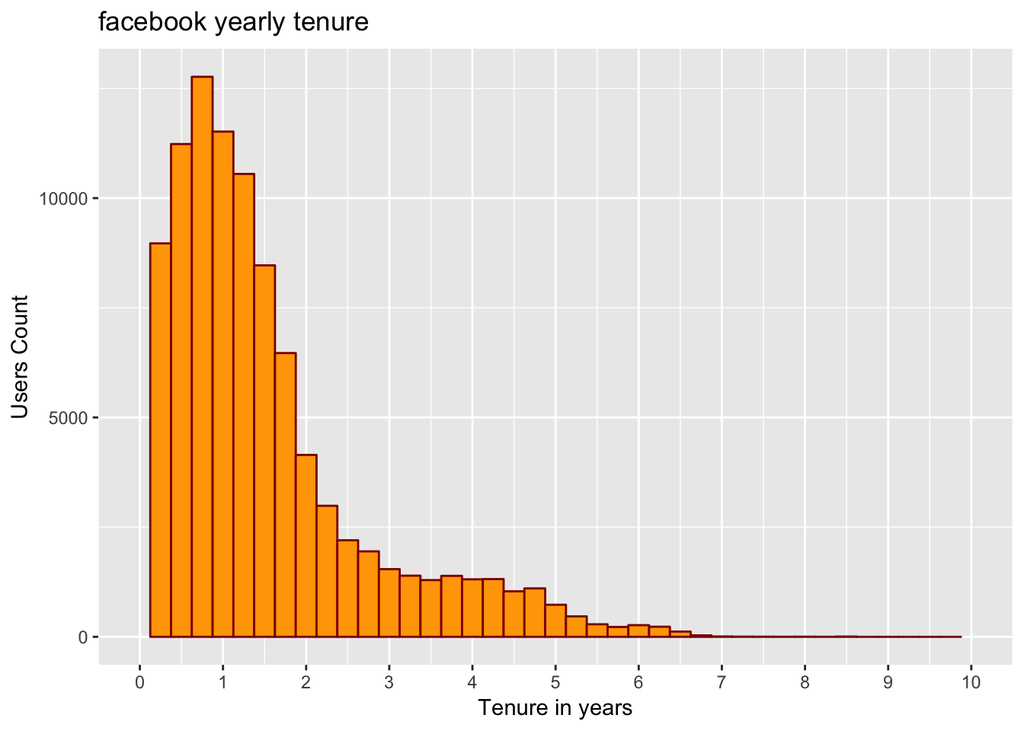

```r
ggplot(data = pf[!is.na(pf$gender),], aes(x = tenure/365 )) +
  geom_histogram(binwidth = .25, color = "dark red", fill = "orange") +
  scale_x_continuous(limits = c(0, 10), breaks = seq(0,10,1)) +
  labs(title = "facebook yearly tenure", x = "Tenure in years", y = 'Users Count')
```

### User Ages

Notes:

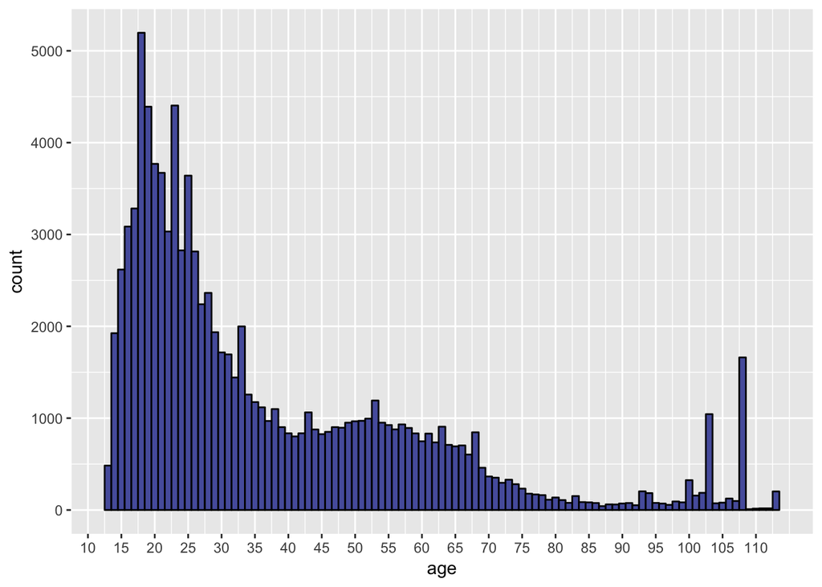

```r
ggplot(aes(x = age), data = pf) +
  geom_histogram(binwidth = 1, fill = '#5760AB', color = 'black') +
  scale_x_continuous(breaks = seq(0, 113, 5))
```

#### What do you notice?

Response:

### The Spread of Memes

Notes:

### Lada’s Money Bag Meme

Notes:

### Transforming Data

Notes: Engagement variables with higher magnitude of data. Transform the data by using log or square root. May be turn into normal distribution or known distribution.

### Add a Scaling Layer

Notes: To avoid log of zero, add one to values before applying log. http://ggplot2.tidyverse.org/reference/scale_continuous.html

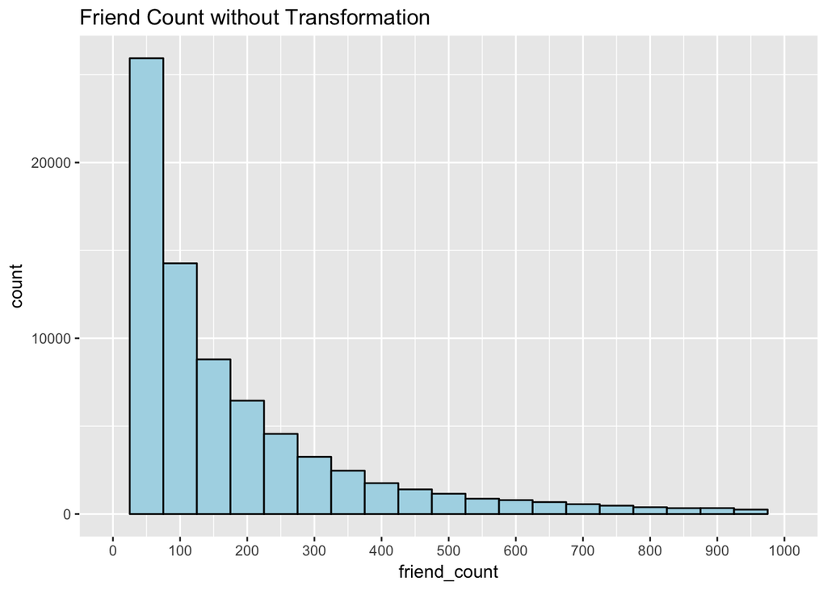

```r
ggplot(data = pf, aes(x = friend_count)) +
  geom_histogram(binwidth = 50, color = 'black', fill = 'light blue') +
  scale_x_continuous(limits = c(0,1000), breaks = seq(0, 1000, 100)) +
  labs( title = 'Friend Count without Transformation')
```

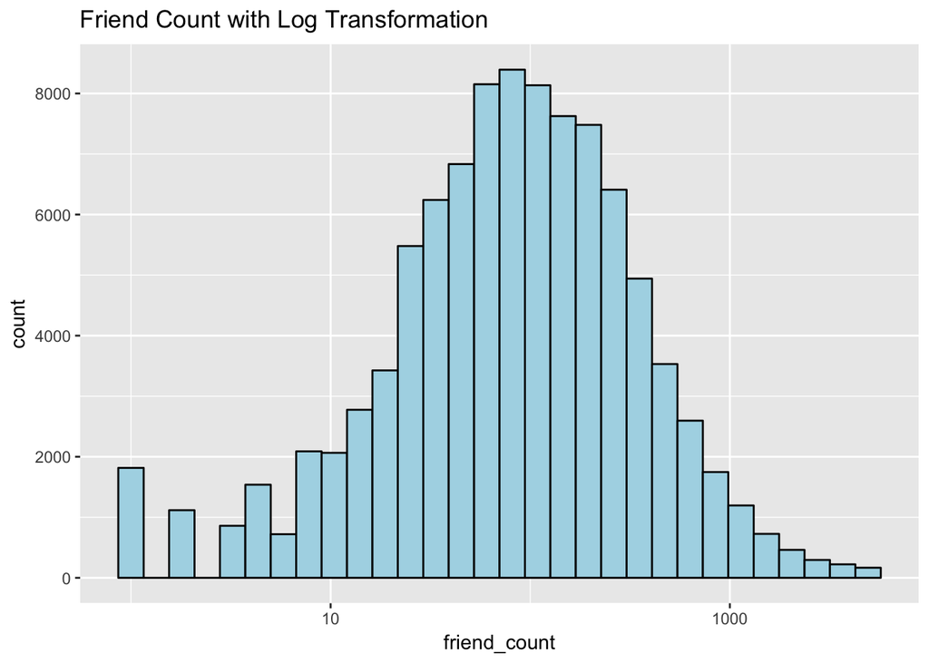

```r
ggplot(data = pf, aes(x = friend_count )) +
  geom_histogram( color = 'black', fill = 'light blue') +
  scale_x_log10() +
  labs(title = 'Friend Count with Log Transformation')
```

[figure not shown]

```r
ggplot(data = pf, aes(x = friend_count )) +
  geom_histogram( color = 'black', fill = 'light blue') +
  scale_x_sqrt() +
  labs(title = 'Friend Count with Log Transformation')
```

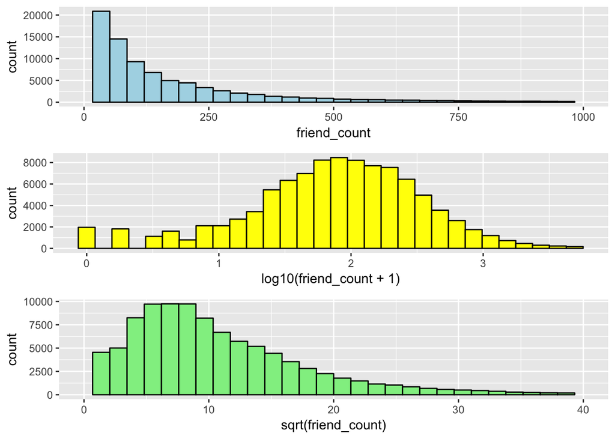

```r
###All independent plot in one canvas
#install.packages("gridExtra", dependencies = T)
library(gridExtra)
p1 = ggplot(data = pf, aes(x = friend_count)) +
  geom_histogram( color = 'black', fill = 'light blue') +
  scale_x_continuous(limits = c(0,1000))
p2 = ggplot(data = pf, aes(x = log10(friend_count + 1))) +
  geom_histogram( color = 'black', fill = 'yellow')
p3 = ggplot(data = pf, aes(x = sqrt(friend_count))) +
  geom_histogram( color = 'black', fill = 'light green') +
  scale_x_continuous(limits = c(0,40))
grid.arrange(p1, p2, p3, ncol = 1)
```

### Frequency Polygons

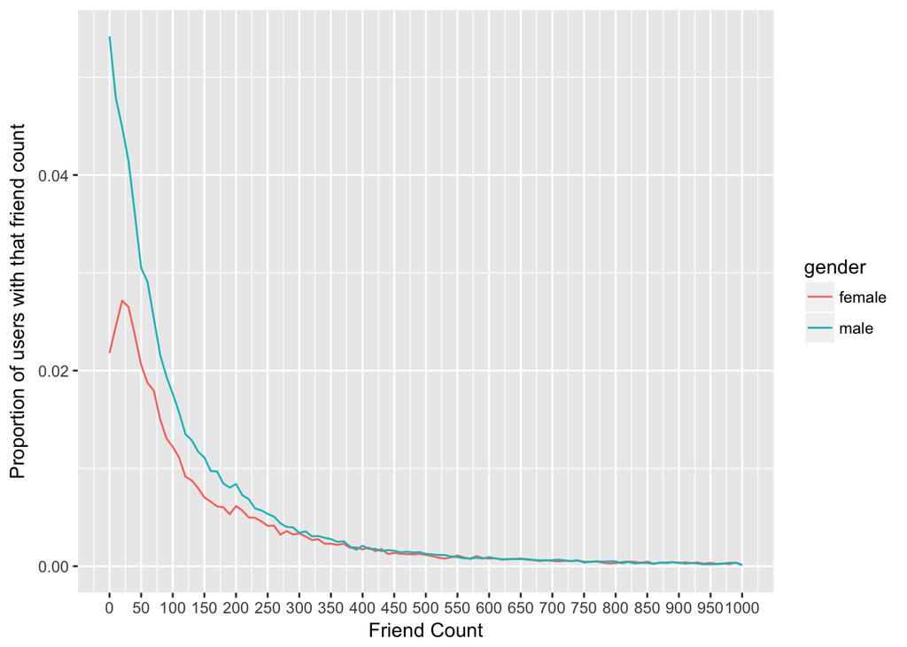

```r
ggplot(aes(x = friend_count, y = ..count../sum(..count..)),
  data = subset(pf, !is.na(gender))) +
  geom_freqpoly(aes(color = gender), binwidth=10) +
  scale_x_continuous(limits = c(0, 1000), breaks = seq(0, 1000, 50)) +
  xlab('Friend Count') +
  ylab('Proportion of users with that friend count')
```

### Likes on the Web

Notes:

[figure not shown]

```r
ggplot(data = pf_na, aes(x = www_likes, y = ..count../sum(..count..))) +
  geom_freqpoly(aes(color = gender)) +
  scale_x_continuous(limits = c(-100,200)) +
  scale_x_log10() +
  xlab('Friend Count') +
  ylab('Proportion of users with Age')
```

### Who has more like, males or female?

```r
likes4females = sum(pf[pf$gender == 'female' & !is.na(pf$gender),]$www_likes)
likes4males = sum(pf[pf$gender == 'male' & !is.na(pf$gender),]$www_likes)
sprintf("Total Men likes = %s", likes4males)
```

```
## [1] "Total Men likes = 1430175"
```

```r
sprintf("Total Women like = %s", likes4females)
```

```
## [1] "Total Women like = 3507665"
```

```r
sprintf("Total Women likes with by = %s", by(data = pf$www_likes, INDICES = pf$gender, FUN = sum)[1])
```

```
## [1] "Total Women likes with by = 3507665"
```

```r
sprintf("Total Men likes with by = %s", by(data = pf$www_likes, INDICES = pf$gender, FUN = sum)[2])
```

```
## [1] "Total Men likes with by = 1430175"
```

### Box Plots

Notes:

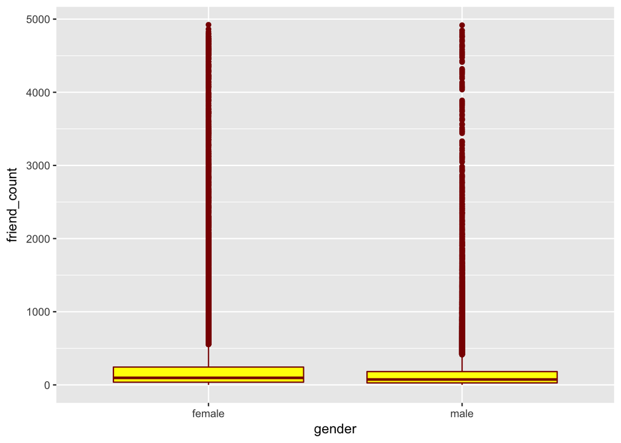

```r
ggplot(data = pf_na, aes(x = gender, y = friend_count)) +
  geom_boxplot(color = 'dark red', fill = 'yellow')
```

#### Adjust the code to focus on users who have friend counts between 0 and 1000.

Did you use the ylim parameter?

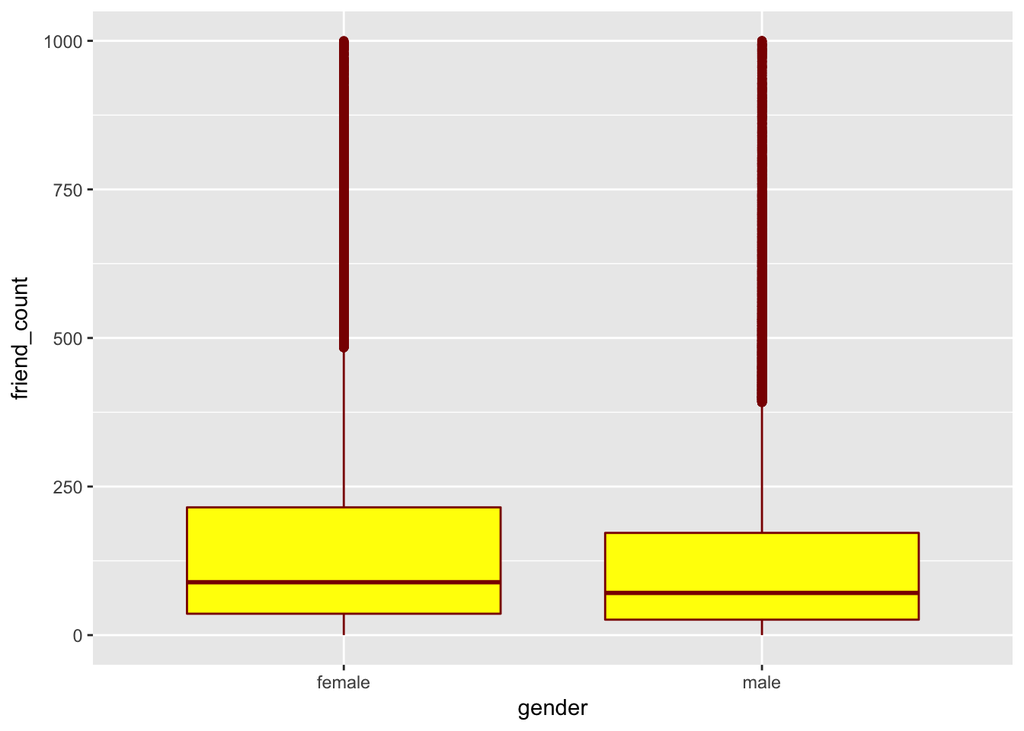

```r
ggplot(data = pf_na, aes(x = gender, y = friend_count)) +
  geom_boxplot(color = 'dark red', fill = 'yellow') +
  scale_y_continuous(limits = c(0,1000))
```

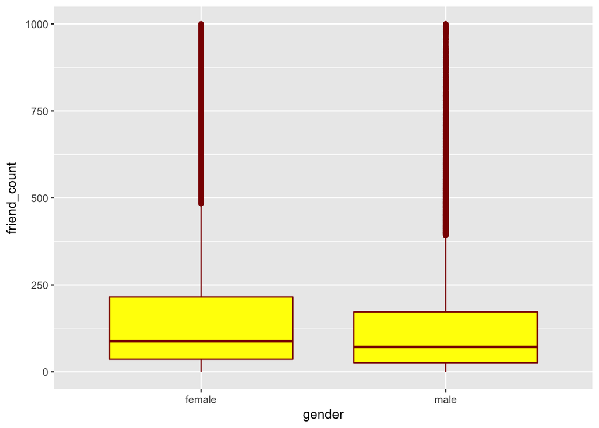

```r
ggplot(data = pf_na, aes(x = gender, y = friend_count)) +
  geom_boxplot(color = 'dark red', fill = 'yellow') +
  ylim(c(0,1000))
```

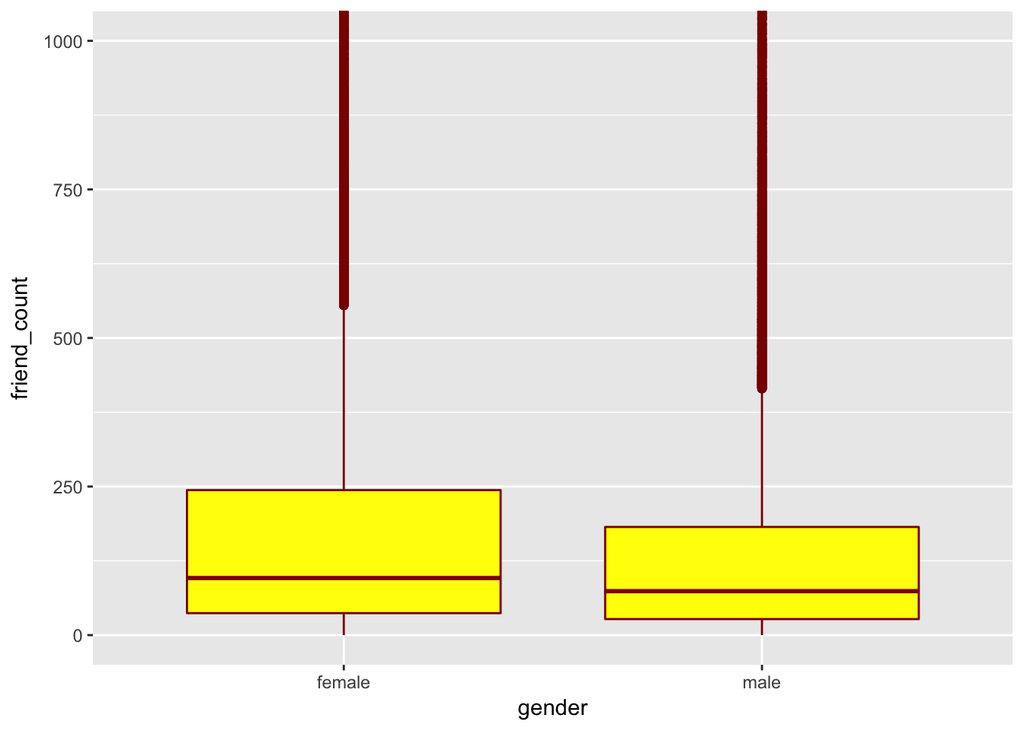

```r
ggplot(data = pf_na, aes(x = gender, y = friend_count)) +
  geom_boxplot(color = 'dark red', fill = 'yellow') +
  coord_cartesian(ylim = c(0,1000))
```

### Box Plots, Quartiles, and Friendships

Notes:

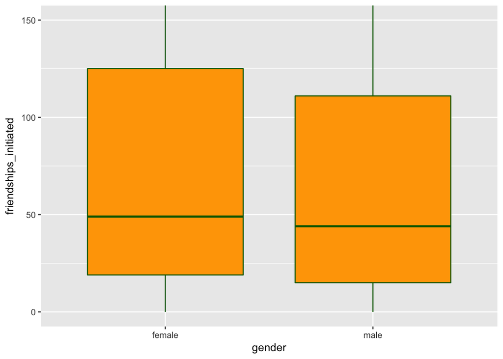

```r
ggplot(data = pf_na, aes(x = gender, y = friendships_initiated)) +
  geom_boxplot(color = 'dark green', fill = 'orange') +
  coord_cartesian(ylim = c(0,150))
```

#### On average, who initiated more friendships in our sample: men or women?

Response:female #### Write about some ways that you can verify your answer. Response:Median and middle 50% is high for female.

Response:

### Getting Logical

Notes:

```r
pf$check_in <- ifelse(pf$likes > 0, 1, 0)
pf$check_in <- factor(pf$check_in)
pf$mobile_check_in <- ifelse(pf$mobile_likes > 0, 1, 0)
pf$mobile_check_in <- factor(pf$mobile_check_in)
(table(pf$mobile_check_in)/table(pf$check_in))*100
```

```
##
##         0         1
## 157.14542  83.37832
```

Response:

### Analyzing One Variable

Reflection:

Click **KnitHTML** to see all of your hard work and to have an html page of this lesson, your answers, and your notes!